# Take Home Exercise #1: Participants in Engagement Ohio

We study a sample of 1011 residents from Engagement, Ohio USA. The information collected is as follows:

**participantId**: unique ID assigned to each participant.

**householdSize**: the number of people in the participant’s household

**haveKids**: whether there are children living in the participant’s household

**age**: participant’s age in years at the start of the study

**educationLevel**: the participant’s educ2ation level, namely Low, HighSchoolorCollege, Bachelors or Graduate

**interestGroup**: a char representing the participant’s stated primary interest-A, B, C, D, E, F, G, H, I, J.

**joviality**: a value ranging from 0 to 1 indicating the participant’s overall happiness level at the start of the study.

David Kwok  
April 24, 2022

# Challenges

There is not an even distribution of demographics by interest group, age or education. This could be representative of the larger population, however it makes identifying specific demographic indicators on happiness and coorelation of demographic traits a little more challenging

# Installing and launching R packages

In order to run generate the data, we need to first install and run the below packages with the below script:

```r
packages <- c('tidyverse','rvest','reshape2','ggtern','viridis','ggrepel','CGPfunctions','ggpubr')

for (p in packages){
  if (!require(p,character.only=T)){
    install.packages(p)
  }
  library(p, character.only=T)
}
```

# Data Preparation and tidying

The data is imported from a local copy of the file *Participants.csv* using the function `read_csv` from the **readr** package, then inspected using the `str()` function using the below code:

```r
Participant_data <- read_csv("Data/Participants.csv")
str(Participant_data)
```

```
spec_tbl_df [1,011 x 7] (S3: spec_tbl_df/tbl_df/tbl/data.frame)
 $ participantId : num [1:1011] 0 1 2 3 4 5 6 7 8 9 ...
 $ householdSize : num [1:1011] 3 3 3 3 3 3 3 3 3 3 ...
 $ haveKids      : logi [1:1011] TRUE TRUE TRUE TRUE TRUE TRUE ...
 $ age           : num [1:1011] 36 25 35 21 43 32 26 27 20 35 ...
 $ educationLevel: chr [1:1011] "HighSchoolOrCollege" "HighSchoolOrCollege" "HighSchoolOrCollege" "HighSchoolOrCollege" ...
 $ interestGroup : chr [1:1011] "H" "B" "A" "I" ...
 $ joviality     : num [1:1011] 0.00163 0.32809 0.39347 0.13806 0.8574 ...
 - attr(*, "spec")=
  .. cols(
  ..   participantId = col_double(),
  ..   householdSize = col_double(),
  ..   haveKids = col_logical(),
  ..   age = col_double(),
  ..   educationLevel = col_character(),
  ..   interestGroup = col_character(),
  ..   joviality = col_double()
  .. )
 - attr(*, "problems")=<externalptr>
```

To facilitate clarity and good house keeping, we renamed the columns to “Participant_ID, Household_Size,”Kids”, “Age”, Education”, “Interest” and “Joviality” using the code below:

```r
 Participant_data <- Participant_data %>% rename(`Participant_ID` = `participantId`,`Household_Size` = `householdSize`, `Kids` = `haveKids`,`Age`=`age`,`Education` =`educationLevel` , `Interest`= `interestGroup`, `Joviality`=`joviality`)
colnames(Participant_data)
```

```
[1] "Participant_ID" "Household_Size" "Kids"
[4] "Age"            "Education"      "Interest"
[7] "Joviality"
```

# Visualizations

We proceed to do preliminary analysis on the data provided by trying to establish demographic details and some things that impact the happiness (or joviality) of the participants ## Demographic Details

We endevor to identify key demographics of the population, we plot a set of charts illustrating the number of people with a given age with a given level of education. We also try to identify the interest in the respective activities broken down by education level. Results are as follows:

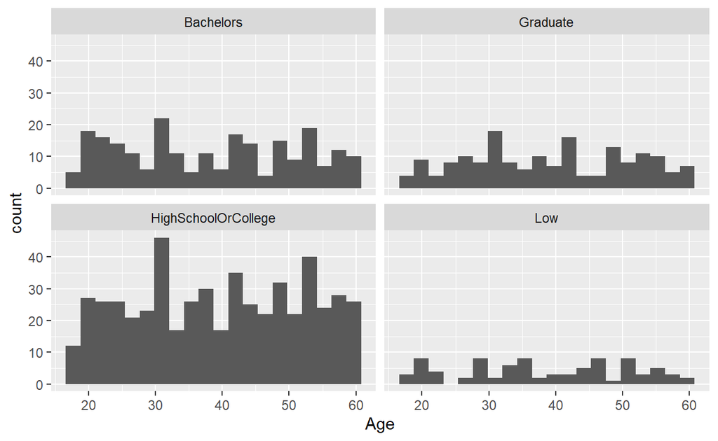

```r
ggplot(data=Participant_data,
       aes(x=Age)) +
    geom_histogram(bins=20) +
facet_wrap(~ Education)
```

The above charts shows a higher incidence of high school or college grads and a significant blip in the population around age 30. Also , there is a relatively small number of lowly educated people.

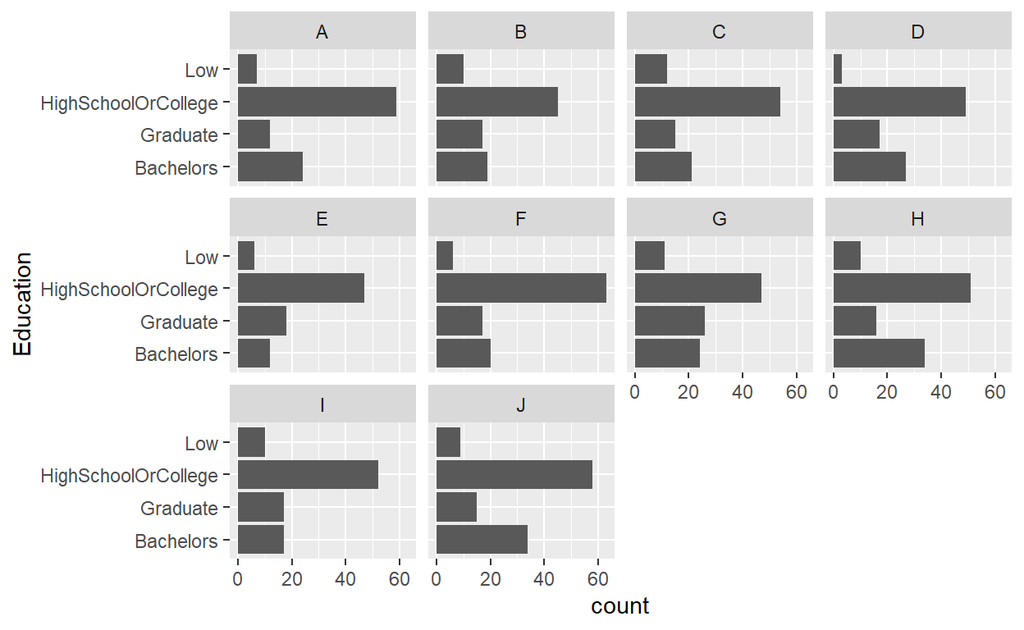

```r
ggplot(data=Participant_data, aes(x=Education)) +
     geom_bar()+facet_wrap(~ Interest) +
coord_flip()
```

## Happiness by Interest Group and Education

We proceed to see the happiness level of the sample. We are doing this through box plots of Joviality against activity, diagrammed by education level to try comparing averages and extremes (100th and 1st percentiles).

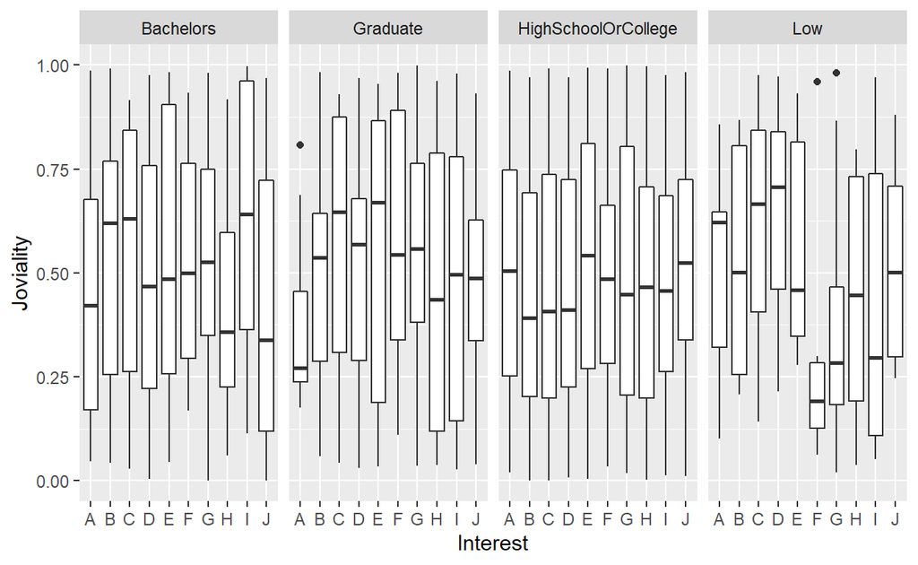

```r
ggplot(data=Participant_data, aes(y = Joviality, x= Interest))+
 geom_boxplot() +
 facet_grid(~Education)
```

## Happiness by education

We explore the impact or possible coorelation of education with happiness through charting a box plot of Joviality against education

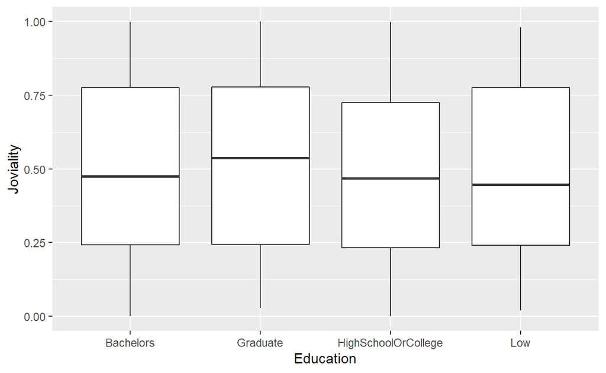

```r
ggplot(data=Participant_data, aes(y = Joviality, x= Education))+
     geom_boxplot()
```